# Capstone bicyle data

Taimur Hassan

2025-02-13

## About case study

This case study explores the usage patterns of Cyclistic, a bike-share company in Chicago, to understand how casual riders and annual members differ in their bike usage. The goal is to provide actionable insights to convert casual riders into annual members, ultimately driving the company’s growth This project is part of the Google Data Analytics Professional Certificate on [link](https://www.coursera.org/professional-certificates/google-data-analytics)

## Step 1: Ask

Company Background

Cyclistic launched its bike-share program in 2016, offering over 5,800 bikes and 600 docking stations across Chicago. The company stands out by providing inclusive options like reclining bikes, hand tricycles, and cargo bikes, catering to riders with disabilities or those who cannot use standard two-wheeled bikes.

Cyclistic offers three pricing plans:

Single-ride passes Full-day passes Annual memberships

Customers who purchase single-ride or full-day passes are classified as casual riders, while those with annual memberships are Cyclistic members.

## Scenario

The marketing team, led by Lily Moreno, aims to convert casual riders into annual members to ensure the company’s future success. To achieve this, the team needs to:

Understand how casual riders and annual members use Cyclistic bikes differently. Develop data-driven marketing strategies to persuade casual riders to become members.

## Key Questions

How do annual members and casual riders use Cyclistic bikes differently? What insights can guide the design of a new marketing strategy?

## Stakeholders

Lily Moreno: Director of Marketing Cyclistic Executive Team  
Cyclistic Marketing Analytics Team

## Step 2 : Prepare

The dataset includes 12 months of bike-share data for 2024, sourced from Divvy Trip Data. The data is organized in CSV files, with each file representing one month of activity. Tools Used

Excel: For initial data inspection and validation & Query RStudio: For data cleaning, analysis and visualization Tableau : For data visualization

## Data Cleaning Process

Installed necessary R packages (tidyverse, skimr, janitor, ggplot2, lubridate, etc.).

Imported and merged 12 monthly CSV files into a single data frame.

Checked for duplicates, missing values, and inconsistencies.

Added new columns using excel

day : Extracted the day of the week from started_at.

Saved the cleaned data as a new CSV file for analysis.

```r
#install.packages("tidyverse")
#install.packages("skimr")
#install.packages("janitor")
#install.packages('ggplot2')
#install.packages("hms")
#install.packages("lubridate")
#install.packages("hms")
```

## Step 3: Process

Data Cleaning Highlights

```r
library(tidyverse)
library(dplyr)
library(skimr)
library(janitor)
```

```r
library(ggplot2)
library(lubridate)
library(hms)
library(readr)
```

### Importing all the cleaned dataframes which are formated as CSV

```r
jan_df <- read.csv("C:/ProgramData/MySQL/MySQL Server 8.0/Uploads/df_jan.csv")
mar_df <- read.csv("C:/ProgramData/MySQL/MySQL Server 8.0/Uploads/df_mar.csv")
feb_df <- read.csv("C:/ProgramData/MySQL/MySQL Server 8.0/Uploads/df_feb.csv")
apr_df <- read.csv("C:/ProgramData/MySQL/MySQL Server 8.0/Uploads/df_apr.csv")
may_df <- read.csv("C:/ProgramData/MySQL/MySQL Server 8.0/Uploads/df_maj.csv")
jun_df <- read.csv("C:/ProgramData/MySQL/MySQL Server 8.0/Uploads/df_jun.csv")
jul_df <- read.csv("C:/ProgramData/MySQL/MySQL Server 8.0/Uploads/df_juli.csv")
aug_df <- read.csv("C:/ProgramData/MySQL/MySQL Server 8.0/Uploads/df_aug.csv")
sep_df <- read.csv("C:/ProgramData/MySQL/MySQL Server 8.0/Uploads/df_sep.csv")
oct_df <- read.csv("C:/ProgramData/MySQL/MySQL Server 8.0/Uploads/df_okt.csv")
nov_df <- read.csv("C:/ProgramData/MySQL/MySQL Server 8.0/Uploads/df_nov.csv")
dec_df <- read.csv("C:/ProgramData/MySQL/MySQL Server 8.0/Uploads/df_dec.csv")
```

## Combine all the dataframes into one

```r
df_2024 <- bind_rows(jan_df,feb_df,mar_df,apr_df,may_df,jun_df,jul_df,aug_df,sep_df,oct_df,nov_df,dec_df)
glimpse(df_2024)
```

```
## Rows: 5,839,496
## Columns: 16
## $ ride_id            <chr> "C1D650626C8C899A", "EECD38BDB25BFCB0", "F4A9CE7806…
## $ rideable_type      <chr> "electric_bike", "electric_bike", "electric_bike", …
## $ day                <chr> "Friday", "Monday", "Saturday", "Monday", "Wednesda…
## $ started_at         <chr> "12/01/2024 15:30", "08/01/2024 15:45", "27/01/2024…
## $ ended_at           <chr> "12/01/2024 15:37", "08/01/2024 15:52", "27/01/2024…
## $ duration_hours     <chr> "00:07", "00:07", "00:08", "00:30", "00:26", "00:09…
## $ start_station_name <chr> "Wells St & Elm St", "Wells St & Elm St", "Wells St…
## $ start_station_id   <chr> "KA1504000135", "KA1504000135", "KA1504000135", "TA…
## $ end_station_name   <chr> "Kingsbury St & Kinzie St", "Kingsbury St & Kinzie …
## $ end_station_id     <chr> "KA1503000043", "KA1503000043", "KA1503000043", "13…
## $ start_lat          <dbl> 41.90, 41.90, 41.90, 41.88, 41.95, 41.90, 41.90, 41…
## $ start_lng          <dbl> -87.63, -87.63, -87.63, -87.63, -87.68, -87.63, -87…
## $ end_lat            <dbl> 41.89, 41.89, 41.89, 41.92, 41.89, 41.89, 41.89, 41…
## $ end_lng            <dbl> -87.64, -87.64, -87.64, -87.64, -87.64, -87.64, -87…
## $ member_casual      <chr> "member", "member", "member", "member", "member", "…
## $ X                  <lgl> NA, NA, NA, NA, NA, NA, NA, NA, NA, NA, NA, NA, NA,…
```

```r
head(df_2024)
```

```
##            ride_id rideable_type       day       started_at         ended_at
## 1 C1D650626C8C899A electric_bike    Friday 12/01/2024 15:30 12/01/2024 15:37
## 2 EECD38BDB25BFCB0 electric_bike    Monday 08/01/2024 15:45 08/01/2024 15:52
## 3 F4A9CE78061F17F7 electric_bike  Saturday 27/01/2024 12:27 27/01/2024 12:35
## 4 0A0D9E15EE50B171  classic_bike    Monday 29/01/2024 16:26 29/01/2024 16:56
## 5 33FFC9805E3EFF9A  classic_bike Wednesday 31/01/2024 05:43 31/01/2024 06:09
## 6 C96080812CD285C5  classic_bike    Sunday 07/01/2024 11:21 07/01/2024 11:30
##   duration_hours         start_station_name start_station_id
## 1          00:07          Wells St & Elm St     KA1504000135
## 2          00:07          Wells St & Elm St     KA1504000135
## 3          00:08          Wells St & Elm St     KA1504000135
## 4          00:30     Wells St & Randolph St     TA1305000030
## 5          00:26 Lincoln Ave & Waveland Ave            13253
## 6          00:09          Wells St & Elm St     KA1504000135
##            end_station_name end_station_id start_lat start_lng end_lat end_lng
## 1  Kingsbury St & Kinzie St   KA1503000043     41.90    -87.63   41.89  -87.64
## 2  Kingsbury St & Kinzie St   KA1503000043     41.90    -87.63   41.89  -87.64
## 3  Kingsbury St & Kinzie St   KA1503000043     41.90    -87.63   41.89  -87.64
## 4 Larrabee St & Webster Ave          13193     41.88    -87.63   41.92  -87.64
## 5  Kingsbury St & Kinzie St   KA1503000043     41.95    -87.68   41.89  -87.64
## 6  Kingsbury St & Kinzie St   KA1503000043     41.90    -87.63   41.89  -87.64
##   member_casual  X
## 1        member NA
## 2        member NA
## 3        member NA
## 4        member NA
## 5        member NA
## 6        member NA
```

```r
dim(df_2024)
```

```
## [1] 5839496      16
```

```r
sum(duplicated(df_2024))
```

```
## [1] 158
```

## Step 4: Analyze

#### Key Insights

Ride Duration:

Average ride duration: ~11 minutes. Longest ride: 23 hours 46 minutes. Shortest ride: 0.039 seconds (likely a data error).

#### Popular Days:

Saturday had the highest number of rides, followed by Wednesday. Monday was the least popular day.

#### Bike Types:

Only electric bikes, electric scooters, and classic bikes were used in 2024. None of the inclusive bike options (e.g., reclining bikes, hand tricycles) were rented.

#### Rider Types:

Casual riders accounted for over 2 million rides. Members used bikes more frequently on weekdays eg wednesday, while casual riders dominated weekends.

## Plot 1 - Total riders 2024

The first plot includes the total number of riders in 2024 compared by casual bike riders and annual member Here is a link for a more detailed version [link](https://public.tableau.com/app/profile/taimur.hassan7268/viz/Total_i%20ders2024/TotalRiders)

[figure not shown]

## Plot 2 - Total riders per day 2024

The second plot shows the total number of rides by both casuals and members in a bar chart in descending order [click](https://public.tableau.com/app/profile/taimur.hassan7268/viz/Total_ridersperday/Ridesperday)

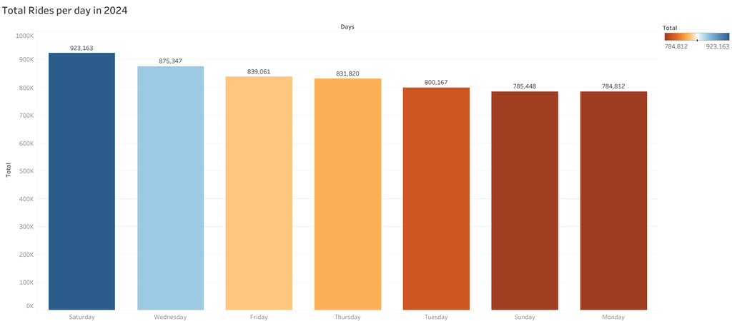

## Plot 3 - Casuals riders per day 2024

This plot will showcase the total number of casual riders per day in year 2024 [Click](https://public.tableau.com/app/profile/taimur.hassan7268/viz/Casualsday_2024/Casuals2024)

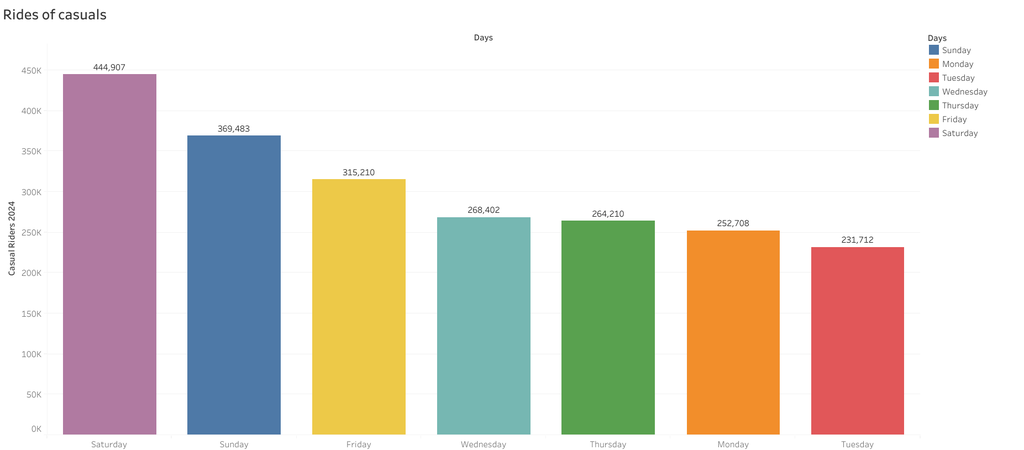

## Plot 4 - Annual members riders per day

This plot shows the sum of annual members in year 2024 [Click](https://public.tableau.com/app/profile/taimur.hassan7268/viz/Member_days2024/Members2024)

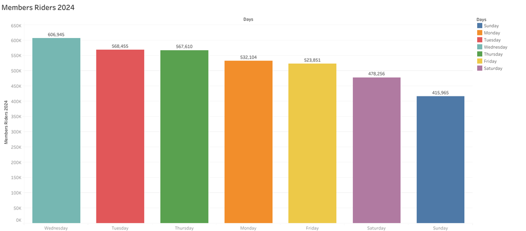

## Plot 5 - Bikes Types usage

This plot shows the different types of bikes used for rides taken during year 2024 [Click](https://public.tableau.com/app/profile/taimur.hassan7268/viz/biketypesperday/Ridestypes)

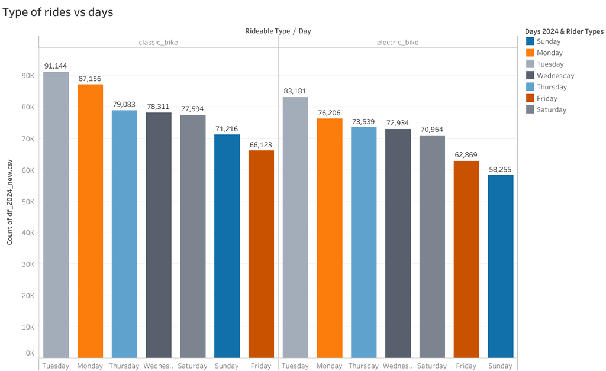

## Plot 6 - Top Stations

This top showcase the top station used by riders in year 2024 [Click](https://public.tableau.com/app/profile/taimur.hassan7268/viz/TopStations_17395357710120/Top15Stations)

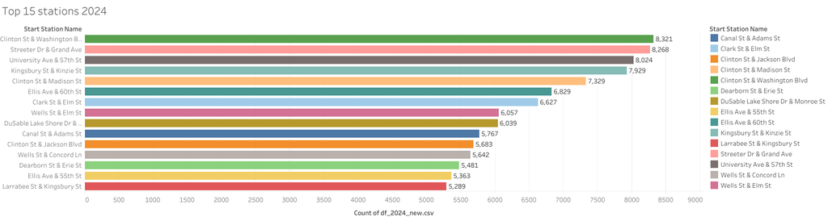

## Plot 7 - Dashboard

This plot shows a summary of the types of bikes used and which top stations were used during year 2024 [Click](https://public.tableau.com/app/profile/taimur.hassan7268/viz/topstations_biketype/Dashboard2)

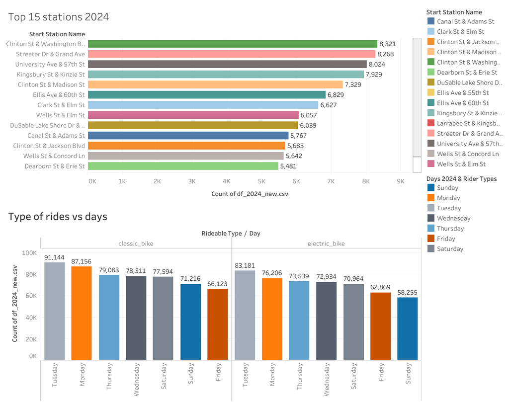

## Plot 8 - Dashboard 2

This plot compares the total number of annual and causal riders by days in year 2024 and showcases which days the riders prefered to ride [Click](https://public.tableau.com/app/profile/taimur.hassan7268/viz/Member_casuals_2024/Dashboard1)

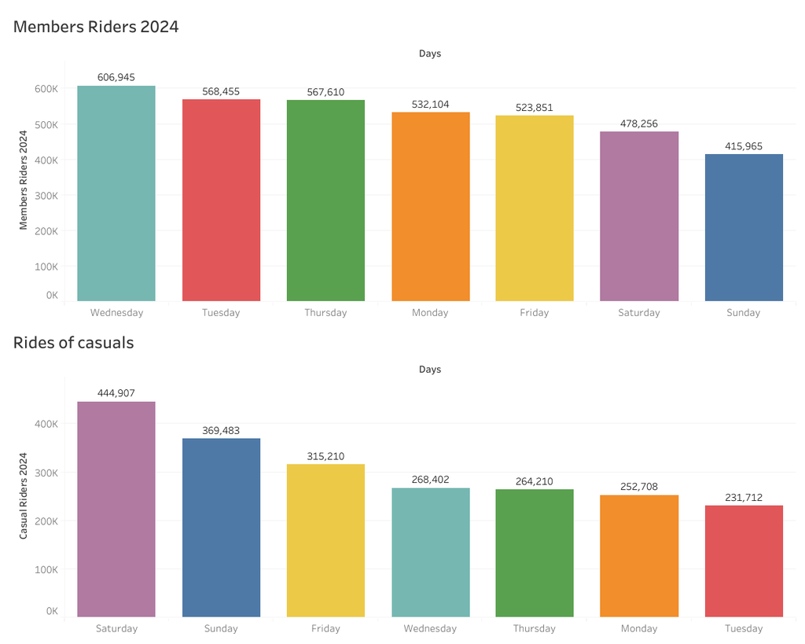

## Step 5: Share

All the plot that are used for visualization has been mentioned above

## Deliverable

A detailed RMarkdown notebook shared on Kaggle for public access Clear visualizations and key findings to support decision-making.

## Step 6: Act

Recommendations

Promote Inclusive Bikes:

Conduct surveys to understand why inclusive bikes (e.g., reclining bikes, hand tricycles) are underutilized.

Offer discounts or promotions to encourage riders to try these options.

Target Casual Riders:

Introduce flexible membership plans (e.g., monthly subscriptions) to attract casual riders.

Offer incentives, such as discounted annual memberships or bonus ride credits.

Weekend Promotions:

Launch weekend-specific promotions for casual riders at popular stations.

Highlight the benefits of membership, such as cost savings and convenience.

## Conclusion

This analysis provides valuable insights into the differences between casual riders and annual members. By implementing targeted marketing strategies, Cyclistic can effectively convert casual riders into loyal members, driving long-term growth and success. Next Steps

Share findings with the Cyclistic executive team for approval.

Develop and test marketing campaigns based on the recommendations.

Monitor the impact of new strategies and refine them as needed.